# Spatial Cueing Experiment

Pierce Edmiston

April 17, 2015

```r
source("R/loaders.R")
cueing <- get_spatial_cueing()
```

```
## [1] "Compiling raw data..."
## [1] "Recoding variables..."
## [1] "Dropping practice trials..."
```

```r
cueing %>% group_by(subj_id) %>%
  summarize(num_trials = n(),
            mean_acc = mean(is_correct))
```

```
## Source: local data frame [32 x 3]
##
##     subj_id num_trials  mean_acc
## 1  SPC3_301        360 0.9777778
## 2  SPC3_302        360 0.9472222
## 3  SPC3_303        360 0.9361111
## 4  SPC3_304        360 0.8666667
## 5  SPC3_305        360 0.7000000
## 6  SPC3_306        360 0.9722222
## 7  SPC3_307        360 0.9722222
## 8  SPC3_308        360 0.9472222
## 9  SPC3_309        360 0.6472222
## 10 SPC3_310        360 0.8472222
## 11 SPC3_311        360 0.9361111
## 12 SPC3_312        360 0.9416667
```

[output cut: 20 more lines]

# Cueing effect in accuracies

Fit a `glmer` model to estimate the effects of cueing with a word and cueing with a visual frame on go/no-go accuracy. Calculate the cueing effects by comparing performance in each cueing condition to performance on the nocue trials.

I expect to find that cueing with a word leads to a bigger jump in go/no-go performance than cueing with a visual frame, because this demanding task requires the type of attentive state that words are better at activating than “motivated” cues like the visual frame.

## Plot by-subject accuracies

1. Compute by-subject accuracies

```r
cueing_by_subj <- cueing %>% group_by(subj_id, cue_type) %>%
  summarize(accuracy = mean(is_correct))
```

2. Arrange cue types on the x-axis

```r
source("R/recoders.R")
cueing_by_subj$cue_type_int <- recode_cue_type_as_int(cueing_by_subj)
cueing_by_subj$cue_type_jit <- jitter_cue_type_int_by_subj(cueing_by_subj)
```

3. Plot of subject accuracies by cue type

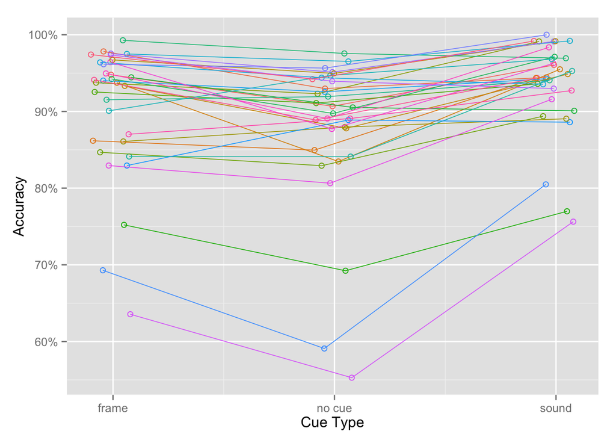

```r
library(ggplot2)
library(scales)

by_subj_point_shape <- 1
by_subj_line_size <- 0.3

plot_bysubj <- ggplot(cueing_by_subj,
    aes(x = cue_type_int, y = accuracy)) +
  geom_point(aes(x = cue_type_jit, color = subj_id), shape = by_subj_point_shape) +
  geom_line(aes(x = cue_type_jit, color = subj_id), size = by_subj_line_size) +
  scale_cue_type_int +
  scale_y_continuous("Accuracy", labels = percent) +
  theme(legend.position = "none")
plot_bysubj
```

Note the three outliers.

```r
cueing_by_subj %>% filter(accuracy[cue_type == "nocue"] < 0.7)
```

```
## Source: local data frame [9 x 5]
## Groups: subj_id
##
##    subj_id cue_type  accuracy cue_type_int cue_type_jit
## 1 SPC3_305    frame 0.6929134           -1  -1.04593307
## 2 SPC3_305    nocue 0.5909091            0  -0.04593307
## 3 SPC3_305    sound 0.8048780            1   0.95406693
## 4 SPC3_309    frame 0.6355932           -1  -0.92195096
## 5 SPC3_309    nocue 0.5528455            0   0.07804904
## 6 SPC3_309    sound 0.7563025            1   1.07804904
## 7  SPC_325    frame 0.7521368           -1  -0.95029342
## 8  SPC_325    nocue 0.6923077            0   0.04970658
## 9  SPC_325    sound 0.7698413            1   1.04970658
```

## Fit glmer model to raw accuracies

1. Set the contrast codes

```r
source("R/recoders.R")
cueing <- set_treatment_contrasts(cueing)
contrasts(cueing$cue_type)
```

```
##       frame sound
## nocue     0     0
## frame     1     0
## sound     0     1
```

2. Predict likelihood of error from cue type
- leaving the outlier subjects in for now
- errors are false alarms and misses

```r
library(lme4)
accuracy_mod <- glmer(data = cueing, family = "binomial",
  formula = is_correct ~ frame_v_nocue + sound_v_nocue +
              (frame_v_nocue + sound_v_nocue || subj_id))
  ## the double pipe fits random intercepts and slopes without
  ## random effect correlations
summary(accuracy_mod)
```

```
## Generalized linear mixed model fit by maximum likelihood (Laplace
##   Approximation) [glmerMod]
##  Family: binomial  ( logit )
## Formula: is_correct ~ frame_v_nocue + sound_v_nocue + (frame_v_nocue +
##     sound_v_nocue || subj_id)
##    Data: cueing
##
##      AIC      BIC   logLik deviance df.resid
##   6590.2   6634.4  -3289.1   6578.2    11514
##
## Scaled residuals:
##     Min      1Q  Median      3Q     Max
## -7.6732  0.1946  0.2606  0.3305  0.8601
##
## Random effects:
##  Groups    Name          Variance  Std.Dev.
##  subj_id   (Intercept)   5.913e-01 7.689e-01
##  subj_id.1 frame_v_nocue 1.192e-10 1.092e-05
##  subj_id.2 sound_v_nocue 4.233e-02 2.057e-01
## Number of obs: 11520, groups:  subj_id, 32
##
## Fixed effects:
##               Estimate Std. Error z value Pr(>|z|)
## (Intercept)    2.18828    0.14678  14.909  < 2e-16 ***
## frame_v_nocue  0.30877    0.07640   4.041 5.31e-05 ***
## sound_v_nocue  0.74625    0.09624   7.754 8.90e-15 ***
## ---
## Signif. codes:  0 '***' 0.001 '**' 0.01 '*' 0.05 '.' 0.1 ' ' 1
##
## Correlation of Fixed Effects:
##             (Intr) frm_v_
## frame_v_noc -0.236
## sound_v_noc -0.191  0.364
```

## Add model predictions to by-subject plot

1. Get the model predictions

```r
library(AICcmodavg)
x_preds <- data.frame(cue_type = c("nocue", "frame", "sound")) %>%
  set_treatment_contrasts()
x_preds$cue_type_int <- recode_cue_type_as_int(x_preds)

y_preds <- predictSE(accuracy_mod, x_preds,
  type = "response", se = TRUE, print.matrix = TRUE)
predictions <- cbind(x_preds, y_preds) %>%
  rename(accuracy = fit, se = se.fit)
```

2. By subject averages with model predictions overlayed

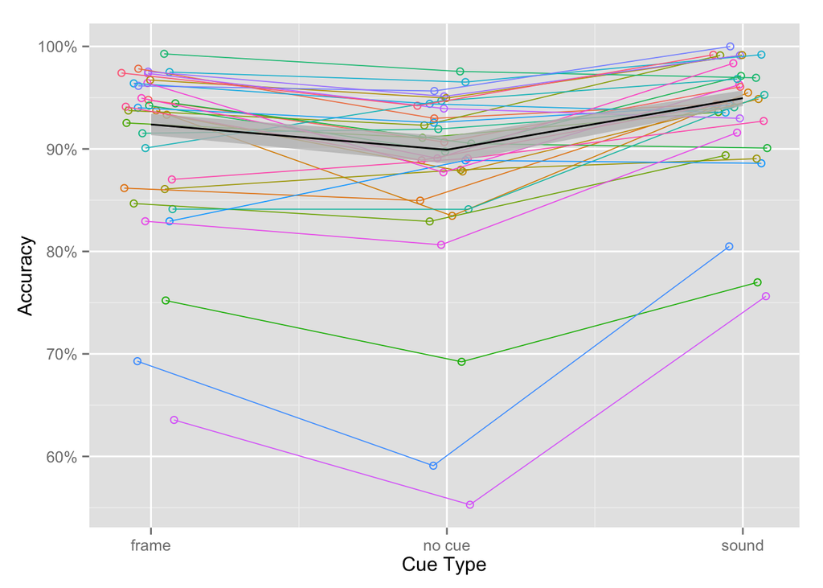

```r
plot_accuracy_mod <- plot_bysubj +
  geom_ribbon(aes(ymin = accuracy - se, ymax = accuracy + se),
    data = predictions, fill = "gray", alpha = 0.8) +
  geom_line(aes(group = 1), data = predictions)
```

## Conclusions

There are reliable boosts in target detection performance both when presented a visual frame and when presented a verbal cue. However, the cueing effect when presented a verbal cue is over twice the cueing effect from the visual frame.

```r
library(broom)
coefficients <- tidy(accuracy_mod, effects = "fixed")
coefficients[2:3, c("term", "estimate", "std.error")]
```

```
##            term  estimate  std.error
## 2 frame_v_nocue 0.3087684 0.07640032
## 3 sound_v_nocue 0.7462520 0.09624054
```

It’s also worth noting that the verbal cueing effect might be underestimated here as performance on verbal cue trials is near ceiling.

## Comparing cueing effects

I can’t simply compare the cueing effects by looking at the interaction between `frame_v_nocue` and `sound_v_nocue` because those variables are treatment contrast coded (the interaction term forces double dipping the data in the nocue condition).

As a temporary workaround, I can estimate the by-subject cueing effects by hand, and fit a simple lmer model on the summarized data.

1. Summarize the frame and sound cueing effects for each subject. Starting with average accuracies in each cueing condition by subject, first cast the frame so that mean accuracy is split into three columns, one for each cueing condition. Calculate the cueing effects by taking the relevant differences in accuracy. Then melt the two difference columns back into tidy format.

```r
library(reshape2)
cueing_effects <- cueing_by_subj %>%
  select(subj_id, cue_type, accuracy) %>%
  dcast(subj_id ~ cue_type, value.var = "accuracy") %>%
  mutate(
    frame_v_nocue = frame - nocue,
    sound_v_nocue = sound - nocue
  ) %>% select(subj_id, frame_v_nocue, sound_v_nocue) %>%
  melt(id.vars = "subj_id", variable.name = "cueing_effect",
       value.name = "accuracy") %>%
  arrange(subj_id)
head(cueing_effects)
```

```
##    subj_id cueing_effect     accuracy
## 1 SPC3_301 frame_v_nocue  0.009782609
## 2 SPC3_301 sound_v_nocue  0.026782609
## 3 SPC3_302 frame_v_nocue  0.019963964
## 4 SPC3_302 sound_v_nocue -0.008516129
## 5 SPC3_303 frame_v_nocue  0.014551105
## 6 SPC3_303 sound_v_nocue  0.017003116
```

2. Fit a simple lmer mod on the summarize data

```r
comparison_mod <- lmer(data = cueing_effects,
  formula = accuracy ~ cueing_effect + (1|subj_id))
## It's ok to use lmer on accuracies here because
## we are comparing the means in two groups
summary(comparison_mod)
```

```
## Linear mixed model fit by REML ['lmerMod']
## Formula: accuracy ~ cueing_effect + (1 | subj_id)
##    Data: cueing_effects
##
## REML criterion at convergence: -209.8
##
## Scaled residuals:
##      Min       1Q   Median       3Q      Max
## -1.46650 -0.40972 -0.02016  0.40428  2.40258
##
## Random effects:
##  Groups   Name        Variance  Std.Dev.
##  subj_id  (Intercept) 0.0012644 0.03556
##  Residual             0.0009146 0.03024
## Number of obs: 64, groups:  subj_id, 32
##
## Fixed effects:
##                            Estimate Std. Error t value
## (Intercept)                0.027560   0.008252   3.340
## cueing_effectsound_v_nocue 0.029052   0.007561   3.842
##
## Correlation of Fixed Effects:
##             (Intr)
## cng_ffcts__ -0.458
```

## Conclusions

As expected, the verbal cueing effect is reliably larger than the visual cueing effect.

```r
t_val <- summary(comparison_mod)$coefficients[2, "t value"]
df_est <- length(cueing$subj_id %>% unique) - 1
p_est <- 1.0 - pt(t_val, df = df_est, lower.tail = TRUE)
p_est
```

```
## [1] 0.000282461
```

# Cueing effect by trial type

Within each cueing condition, there are four types of trials: 1. Hit: Successful detection the target. 2. Miss: Failure to respond when the target was present. 3. False Alarm: “Detection” of a target that was not present. 4. Pass: No target and no response.

Count up the number of trials in each of the trial types above for each of the three cue types and plot the results.

```r
source("R/recoders.R")
cueing$trial_type <- determine_trial_type(cueing)

trial_types_by_subj <- cueing %>%
  group_by(subj_id, cue_type, trial_type) %>%
  summarize(count = n()) %>%
  group_by(subj_id, cue_type) %>%
  mutate(rate = count/sum(count)) %>%
  ungroup()
trial_types_by_subj
```

```
## Source: local data frame [349 x 5]
##
##     subj_id cue_type  trial_type count        rate
## 1  SPC3_301    nocue false_alarm     1 0.008695652
## 2  SPC3_301    nocue         hit    92 0.800000000
## 3  SPC3_301    nocue        miss     2 0.017391304
## 4  SPC3_301    nocue        pass    20 0.173913043
## 5  SPC3_301    frame false_alarm     1 0.008333333
## 6  SPC3_301    frame         hit    95 0.791666667
## 7  SPC3_301    frame        miss     2 0.016666667
## 8  SPC3_301    frame        pass    22 0.183333333
## 9  SPC3_301    sound false_alarm     1 0.008000000
## 10 SPC3_301    sound         hit   109 0.872000000
## ..      ...      ...         ...   ...         ...
```

```r
# position cue type on horizontal axis
trial_types_by_subj$cue_type_int <- recode_cue_type_as_int(trial_types_by_subj)
trial_types_by_subj$cue_type_jit <- jitter_cue_type_int_by_subj(trial_types_by_subj)

# label text will be used in facet headers
trial_types_by_subj$trial_type_lab <- label_trial_type(trial_types_by_subj)
```

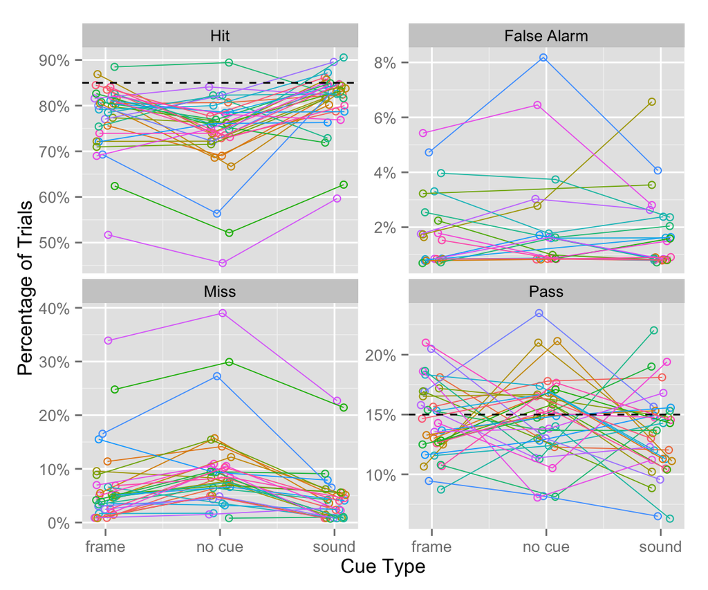

```r
# expected hit rates are 85% and 15%
reference_lines <- data.frame(
  trial_type_lab = c("hit", "pass"),
  expected = c(0.85, 0.15)
)
reference_lines$trial_type_lab <- label_trial_type(reference_lines)

ggplot(trial_types_by_subj, aes(y = rate)) +
  geom_point(aes(x = cue_type_jit, color = subj_id), shape = by_subj_point_shape) +
  geom_line(aes(x = cue_type_jit, color = subj_id), size = by_subj_line_size) +
  facet_wrap("trial_type_lab", ncol = 2, scales = "free_y") +
  geom_hline(aes(yintercept = expected), data = reference_lines, lty = 2) +
  scale_cue_type_int +
  scale_y_continuous("Percentage of Trials", labels = percent) +
  theme(legend.position = "none")
```

## Conclusions

It seems that the verbal cue is improving accuracy by making people more likely to detect the target (not a decrease in false alarms, for example).

# Cueing effect in RTs on hit trials

```r
hit_trials <- filter(cueing, trial_type == 'hit')
```

## Plot by-subject RTs

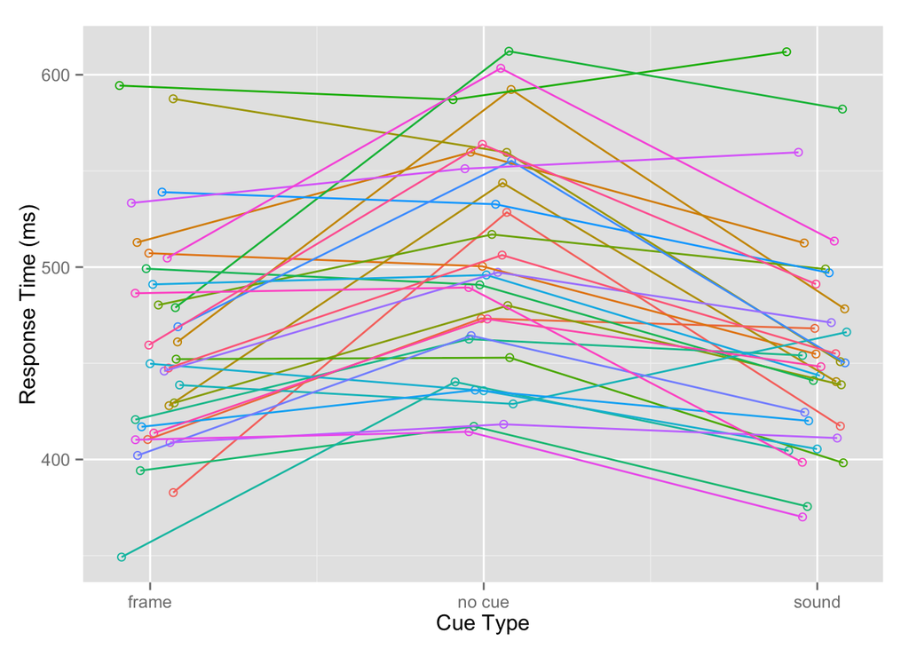

```r
rts_by_subj <- hit_trials %>% group_by(subj_id, cue_type) %>%
  summarize(rt = mean(rt))

rts_by_subj$cue_type_int <- recode_cue_type_as_int(rts_by_subj)
rts_by_subj$cue_type_jit <- jitter_cue_type_int_by_subj(rts_by_subj)

plot_rts_by_subj <- ggplot(rts_by_subj,
    aes(x = cue_type_int, y = rt)) +
  geom_point(aes(x = cue_type_jit, color = subj_id), shape = by_subj_point_shape) +
  geom_line(aes(x = cue_type_jit, color = subj_id), shape = by_subj_line_size) +
  scale_cue_type_int +
  scale_y_continuous("Response Time (ms)") +
  theme(legend.position = "none")
plot_rts_by_subj
```

## Fit lmer model to raw RTs

```r
rt_mod <- lmer(rt ~ frame_v_nocue + sound_v_nocue +
                     (frame_v_nocue + sound_v_nocue || subj_id),
                   data = hit_trials)
summary(rt_mod)
```

```
## Linear mixed model fit by REML ['lmerMod']
## Formula:
## rt ~ frame_v_nocue + sound_v_nocue + ((1 | subj_id) + (0 + frame_v_nocue |
##     subj_id) + (0 + sound_v_nocue | subj_id))
##    Data: hit_trials
##
## REML criterion at convergence: 113622.7
##
## Scaled residuals:
##     Min      1Q  Median      3Q     Max
## -4.2758 -0.4759 -0.1259  0.3662  6.3069
##
## Random effects:
##  Groups    Name          Variance Std.Dev.
##  subj_id   (Intercept)    2808.6   53.00
##  subj_id.1 frame_v_nocue  1667.2   40.83
##  subj_id.2 sound_v_nocue   889.7   29.83
##  Residual                18840.5  137.26
## Number of obs: 8944, groups:  subj_id, 32
##
## Fixed effects:
##               Estimate Std. Error t value
## (Intercept)    502.248      9.730   51.62
## frame_v_nocue  -42.958      8.078   -5.32
## sound_v_nocue  -44.648      6.388   -6.99
##
## Correlation of Fixed Effects:
##             (Intr) frm_v_
## frame_v_noc -0.088
## sound_v_noc -0.111  0.134
```

## Add model predictions to RT plot

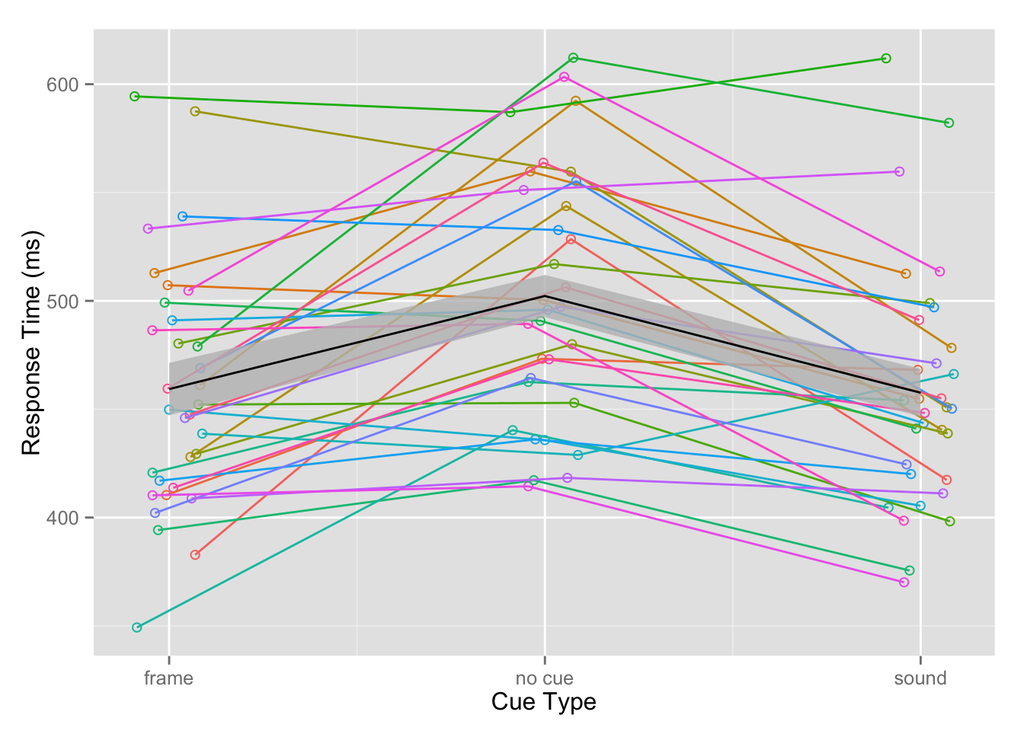

```r
y_preds <- predictSE(rt_mod, x_preds, type = "response", se = TRUE, print.matrix = TRUE)
predictions <- cbind(x_preds, y_preds) %>%
  rename(rt = fit, se = se.fit)

plot_rt_mod <- plot_rts_by_subj +
  geom_ribbon(aes(ymin = rt - se, ymax = rt + se),
    data = predictions, fill = "gray", alpha = 0.8) +
  geom_line(aes(group = 1), data = predictions)
plot_rt_mod
```

## Conclusions

Both types of cues facilitate faster responses when compared to no cue trials, but visual cues and verbal cues did not differ in cueing effects as measured in RTs.